# Лабораторная работа №7

Командная оболочка Midnight Commander

Захаренко А.В.

Российский университет дружбы народов, Москва, Россия

13.03.2023

# Информация

## Докладчик

- Захаренко Анастасия Викторовна
- студентка первого курса бакалавриата
- направление бизнес-информатика, факультет физико-математических и естественных наук
- Российский университет дружбы народов

# Элементы презентации

## Актуальность

Освоение основных возможностей командной оболочки Midnight Commander. Приоб- ретение навыков практической работы по просмотру каталогов и файлов; манипуляций с ними.

## Цели и задачи

Задание по mc Задание по встроенному редактору mc

## Материалы и методы

Командная оболочка — интерфейс взаимодействия пользователя с операционной систе- мой и программным обеспечением посредством команд. Midnight Commander (или mc) — псевдографическая командная оболочка для UNIX/Linux систем. Для запуска mc необходимо в командной строке набрать mc и нажать Enter . Рабочее пространство mc имеет две панели, отображающие по умолчанию списки файлов двух каталогов

## Содержание исследования

Задание по mc 1. Изучите информацию о mc, вызвав в командной строке man mc.

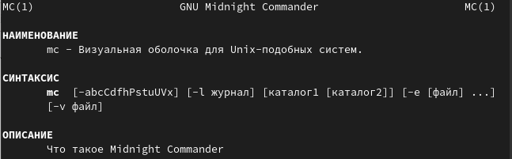

Задание по mc1

2. Запустите из командной строки mc, изучите его структуру и меню
3. Выполните несколько операций в mc, используя управляющие клавиши (операции с панелями; выделение/отмена выделения файлов, копирование/перемещение фай- лов, получение информации о размере и правах доступа на файлы и/или каталоги и т.п.)

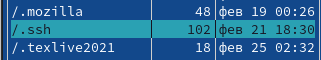

Задание по mc3

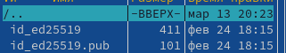

Задание по mc3.1

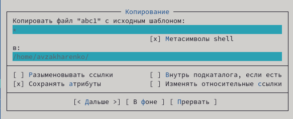

Задание по mc3.2

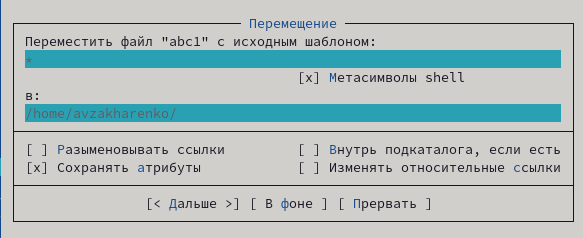

Задание по mc3.3

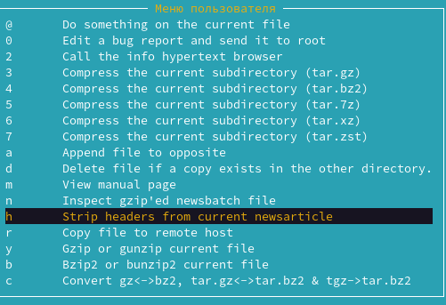

Задание по mc3.4

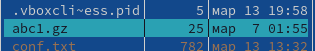

Задание по mc3.5

4. Выполните основные команды меню левой (или правой) панели. Оцените степень подробности вывода информации о файлах.

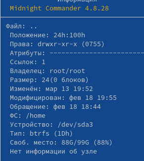

Задание по mc4

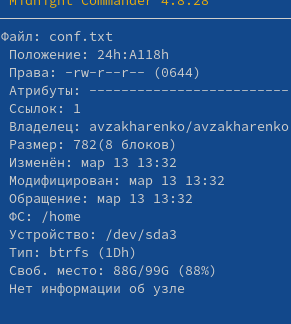

Задание по mc4.1

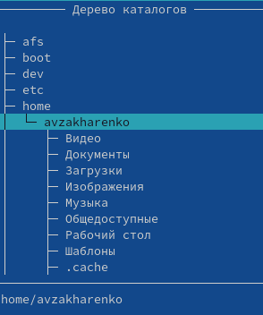

Задание по mc4.2

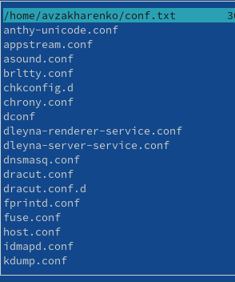

Задание по mc4.3

5. Используя возможности подменю Файл , выполните: – просмотр содержимого текстового файла;

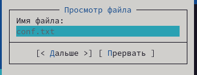

Задание по mc5

– редактирование содержимого текстового файла (без сохранения результатов редактирования);

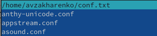

Задание по mc5.1

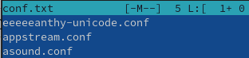

Задание по mc

– создание каталога;

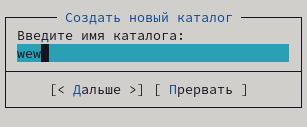

Задание по mc5.2

– копирование в файлов в созданный каталог.

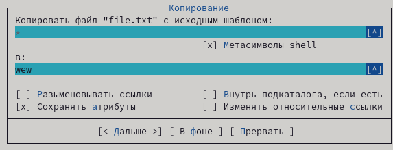

Задание по mc5.3

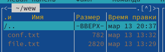

Задание по mc5.4

6. С помощью соответствующих средств подменю Команда осуществите: – поиск в файловой системе файла с заданными условиями (например, файла с расширением .c или .cpp, содержащего строку main);

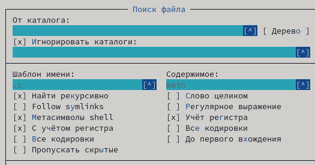

Задание по mc6

– переход в домашний каталог;

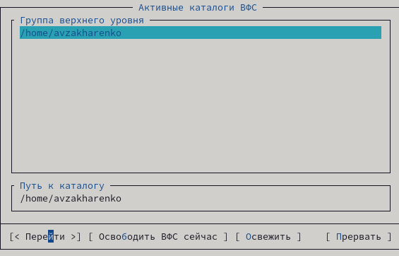

Задание по mc6.1

– анализ файла меню и файла расширений.

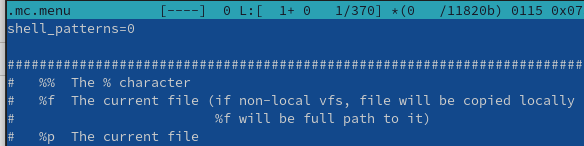

Задание по mc6.2

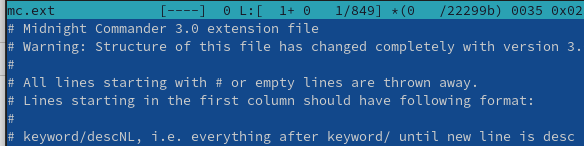

Задание по mc6.3

7. Вызовите подменю Настройки . Освойте операции, определяющие структуру экрана mc (Full screen, Double Width, Show Hidden Files и т.д.)

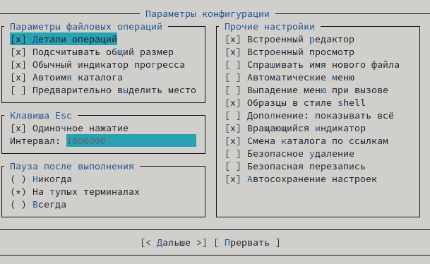

Задание по mc7

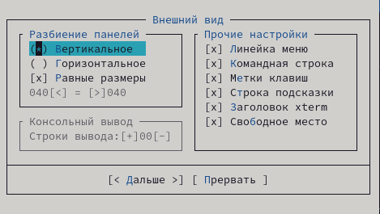

Задание по mc7.1

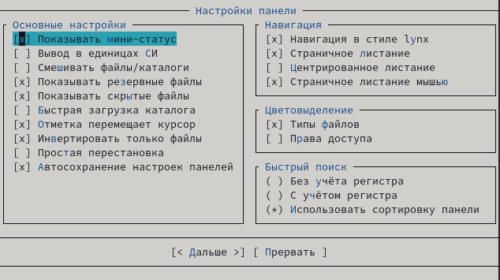

Задание по mc7.2

Задание по встроенному редактору mc 1. Создайте текстовой файл text.txt.

2. Откройте этот файл с помощью встроенного в mc редактора.
3. Вставьте в открытый файл небольшой фрагмент текста, скопированный из любого другого файла или Интернета.

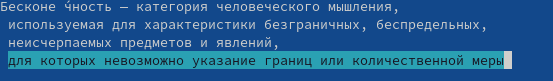

Задание по встроенному редактору mc3

4. Проделайте с текстом следующие манипуляции, используя горячие клавиши: 4.1. Удалите строку текста. 4.2. Выделите фрагмент текста и скопируйте его на новую строку 4.3. Выделите фрагмент текста и перенесите его на новую строку. 4.4. Сохраните файл. 4.5. Отмените последнее действие. 4.6. Перейдите в конец файла (нажав комбинацию клавиш) и напишите некоторый текст. 4.7. Перейдите в начало файла (нажав комбинацию клавиш) и напишите некоторый текст. 4.8. Сохраните и закройте файл.

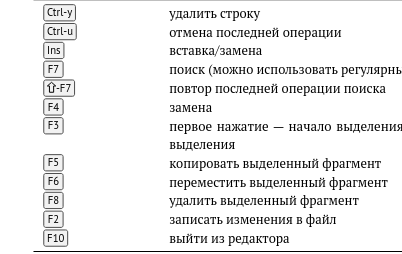

Задание по встроенному редактору mc4

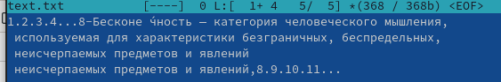

Задание по встроенному редактору mc4.1

5. Используя меню редактора, включите подсветку синтаксиса, если она не включена, или выключите, если она включена

[figure not shown]

## Результаты

Я освоила основные возможности командной оболочки Midnight Commander. Приоб- рела навыки практической работы по просмотру каталогов и файлов; манипуляций с ними.